# **Internship Report**: *Recovery of Early Mistakes in Multistage Tests*

Nikola Sekulovski

10.1.2022 - 18.2.2022

# **Introduction**

*Multistage tests* (MSTs) are considered to be “the best of both worlds” when compared to the traditional Linear Tests (LTs) on the one hand, and Computerized Adaptive Tests (CATs) on the other. They allow for the adaptation of the difficulty of the items, based on the students level of proficiency, without many of the shortcomings that follow when using completely adaptive tests. Briefly, many of the problems that CATs face, such as the lack of control over item order, not being easily applicable to essay items, no possibility of reviewing, the difficulty of programming these tests, etc, are compensated for when using MSTs. Multistage tests can be seen as a series of small sequential batches of items (called modules), where, based on the proficiency estimate in one module, an appropriately difficult following module is administered. Every specific combination of modules can be seen as a separate booklet, which implies that different students (with varying levels of proficiency) can follow different paths (which can be seen as booklets). For more details on MSTs, see, for example, Yan, Von Davier, & Lewis (2016) (pp. 3-20). The particular MST that is studied here is called **ACET** (*Dutch*: Adaptive Centrale Eindtoets), which was developed by [Cito](https://www.cito.com/) for the classification of primary education students on different levels (further reffed to as classes) of secondary education. ACET is comprised of three separate MSTs for measuring *Reading (Lezen)*, *Mathematics (Rekenen)* and *Language proficiency (Taal)*, and a linear test for *Writing (Schrijven)* (throughout this report the Dutch names for the subjects are used). The estimated latent abilities, from administering the tests, are translated into reference scores and the final score for ACET is calculated as a composite of the reference scores of the four subjects (relevant for the second simulation where the focus is on classification errors). The MST design for all three subjects is presented below.

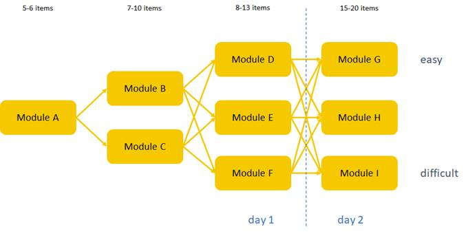

Knowing how MSTs (and adaptive tests in general) work, it is only logical to ask: how fair are these tests when estimating the final ability of the students? More specifically, what happens when, for example, a highly proficient student makes mistakes in the early stages of the MST, and as a result is routed through an easier path? In other words: *to what extent can students “recover” from mistakes made in earlier stage(s) and still reach an estimate close to their true ability?* This is the research question tackled in the work presented in this report. ACET consists of multiple versions for each module on all three subjects. To keep the simulation as simple as possible, a special version of the MST developed for hearing impaired students will be used, which only contains one version per module. Throughout this report, the terms ability, proficiency and $\theta$ (which is the Greek symbol used in [IRT](https://en.wikipedia.org/wiki/Item_response_theory) to represent the latent ability) are used interchangeably. In striving to answer the research question, two simulations studies were conducted.

This report is divided as follows. At the next section the first (initial) simulation, undertaken to explore how these particular MSTs function when we “know” the true ability of the students is presented and results from initial statistical analyses are discussed. Afterwards, the number of errors in Module A and in Day 1, which are used through the rest of the report are briefly introduced. Additionally, the number of different paths, with a special focus on the students located on the extremes of the latent ability distribution, is presented and discussed. In the end of this section, a small statistical “experiment” is used to explore whether there are significant differences in the discrepancy between the true and the re-estimated proficiency between the three subjects when controlling for different covariates. In the second simulation, the observed data from ACET 2021 are used to simulate responses. Afterwards, classification errors as a function of the total number of mistakes in modules A are calculated for each of the classes of secondary education. Additionally, threshold values above which misclassifications tend to appear are presented and discussed. This report ends with a conclusion section, summarizing all the work presented while giving recommendations for the design of ACET and future research on this topic. All the code used to obtain the results presented in this report is openly available on [GitHub](https://github.com/sekulovskin/recovery-MST-Cito). Note, due to the nature of the simulations (more specifically the way the multiple MST responses are generated), exact replications are not possible (even when using the same random seed). Thus, the results might slightly vary. However, the simulations were repeated four times, and roughly similar results were observed. The programming language for statistical computing `R` version 4.1.2 (R Core Team, 2021) was used to perform all the analyses.

# **Initial Analyses (Simulation 1)**

## Outline

In this section, the results from the analyses based on the first simulation are presented. Using the observed distributions of the abilities from the 2021 administration of ACET and adding the theoretically possible extreme values on the edges (which otherwise weren’t likely to be simulated when only using the observed distributions), 200 $\theta$ values for each subject were generated and treated as the true abilities of 200 artificial students. A summary of these ability distributions is presented below.

| **True abilities** | **N = 200**<sup>1</sup> |
| --- | --- |
| Lezen | 0.19 (0.51) [-2.54, 3.40] |
| Rekenen | 0.30 (0.47) [-1.97, 1.85] |
| Taal | 0.26 (0.42) [-1.70, 2.12] |

<sup>*1*</sup> Mean (SD) [Range]

Afterwards, ACET’s test design, routing rules and the item parameters, for each subject, were used to generate a 1000 MST responses for each artificial student (i.e., for each true $\theta$). These responses were simulated using the `sim_mst` function from the package `dexterMST` (Bechger, Koops, Partchev, & Maris, 2021), which simulates data from an Extended Nominal Response Model. Afterwards, using the `ability` function from the package `dexter` (Maris, Bechger, Koops, & Partchev, 2021), re-estimates of the true ability were obtained with Weighted Likelihood Estimation (WLE) for all 1000 simulated responses for the 200 students for each of the three subjects (resulting in 200000 different response patterns for each subject). This plethora of responses for each level of ability allows to, separately, explore how the ability estimate for each of the three subjects changes when certain factors, such as the number of mistakes in Module A, the number of mistakes in Day 1 and different MST paths are varied.

## Welch tests

To preliminary inspect whether different patterns produced by the multiple simulated responses for each level of the true ability lead to differences between the true and the re-estimated $\theta$, simple [Welch Tests](https://en.wikipedia.org/wiki/Welch%27s_t-test) were executed comparing each true $\theta$ and the mean of the re-estimated $\theta's$ for each subject. Briefly, the goal here was to inspect whether there is a *statistically significant* difference between the true and the average of the re-estimated $\theta's$ for each level of the true latent ability. However, this is done out of pure exploratory reasons and the p-values are always “taken with a grain of salt,” since they can be quite misleading, especially when having a big sample size (which in this case is a 1000 - the number of simulations per true ability), the interested reader is referred to Cohen (1994) for further elaborations on the issues with standard Null Hypothesis Testing. Since we are dealing with a “large enough” sample size we will use the value of $\alpha = .01$ as a cutoff for whether a mean difference is significant.

| **Lezen** | **N = 200**<sup>1</sup> |
| --- | --- |
| p values | 0.40 (0.31) [0.00, 0.97], |

<sup>*1*</sup> Mean (SD) [1%, 99%],

More specifically, the observed significant differences were for $\theta$ values of -2.54, -1.8, -1.5, -1.3, -1.2, -1, -0.9, -0.8, -0.007, 0.08, 0.13, 0.4, 0.43, 1.2, 1.4, 1.7, 2.2 and 3.4, which correspond to reference Lezen scores of 0, 2, 3, 4, 5, 7, 9, 11, 46, 51, 54, 66, 66, 80, 81, 82, 83 and 84, respectively. This indicates that most of the mismatches between the true and the re-estimated ability tend to be on the extreme, however, there are also a few values in the middle of the ability range.

| **Rekenen** | **N = 200**<sup>1</sup> |
| --- | --- |
| p values | 0.47 (0.30) [0.00, 0.99], |

<sup>*1*</sup> Mean (SD) [1%, 99%],

The mean p-value for Rekenen is higher than for Lezen, roughly indicating fewer problems with high discrepancies, however, the 98% interval still contains the cutoff of 0.01.

In this case significant differences were found for the $\theta$ values -1.97, -1.43, -1.17, -0.16, 0.042, 0.21, 0.23, 0.27, 0.5, 0.93 and 1.85 corresponding to reference Rekenen scores of 1, 2, 3, 16, 21, 25, 25, 27, 31, 37 and 40 respectively.

| **Taal** | **N = 200**<sup>1</sup> |
| --- | --- |
| p values | 0.44 (0.31) [0.00, 0.99], |

<sup>*1*</sup> Mean (SD) [1%, 99%],

The mean p-value for Taal is somewhere in between Rekenen and Lezen.

Here significant differences were found for $\theta$ values -1.7, -1.3, -0.03, 0.012, 0.07, 0.18, 0.304, 0.36, 0.46, 0.6, 1.4, 1.6, 1.8 and 2.12 corresponding to reference Taal scores of 0, 1, 35, 36, 42, 49, 55, 58, 61, 64, 68, 69, 70 and 70 respectively.

**Conclusion:** Based on the presented preliminary analyses, it can be seen that when we do not control for any variables, and just inspect whether there is a difference between the true and the average of the re-estimated $\theta's$ for each true ability:

- *Lezen* has the highest magnitude of significant results (having the lowest mean p-value), with 9%of the true abilities significantly differing from their mean re-estimated counterparts (with most being on the extremes of the latent ability distribution);
- *Rekenen* has the smallest magnitude of significant results (having the highest mean p-value) with around 5.5 % of the true abilities significantly differing from their mean re-estimated counterparts. However, in this case, mismatches were slightly more evenly spread out through the whole latent ability continuum;
- *Taal* is somewhere in the middle both in terms of the magnitude of p-values and also in terms of the percentage of $\theta$ values significantly differing from their mean re-estimates, which in this case was 7%.

Based on these first basic rudimentary analyses on the simulated MST responses, it can be concluded that mismatches between the true and the re-estimated proficiency do appear. The subject Rekenen, by far is the least problematic. However, we cannot say whether the Lezen or Taal MST performs better since the spread of the latent ability for Lezen is quite wider than for Taal (see, the first table). These results give reason to continue to explore why this is the case by considering different aspects of the MST, which is done in the sections that follow.

## Number of early mistakes

Since it is in the inherent nature of an MST that the performance in the early (or even the first) module is crucial in deciding in which module will a student be routed in the following stage (see, Introduction) it is important to consider students responses on the early stages. Thus, `R` scripts that calculate the number of mistakes in Module A *and* the number of mistakes on Day 1 were written and used both in this simulation and in the one presented in the next section. In ACET students are either awarded the maximum number of points or no points, thus a mistake is defined as a score of zero on a particular item.

Here the repeated re-estimates for the true abilities that showed significant differences in the first analyses were separated with respect to the number of mistakes in module A to see whether the observed significant differences can be attributed to the number of errors. No statistical significance tests were implemented in this situation since the number of replications for each level of mistakes is highly variable, which would’ve resulted in p-values that make little sense. Thus, a tabular representation of these results for each subject are presented below. Here the mean number of mistakes for each number of mistakes on each of the significant proficiency found in the first analyses are presented (for all three subjects). Moreover, plots of the same results are given in the Appendix. These analyses will not be repeated for the number of mistakes on Day 1, since, as can be seen from the ACET MST design presented in the introduction, these represent the sum of mistakes in stages 1 2 and 3, which means that separating on a wide range of number is not very insightful. However, the number of mistakes on Day 1 is used as a covariate in the main statistical analysis presented at the end of this section.

### Mistakes in Module A

#### Lezen

| 0 | 1 | 2 | 3 | 4 | 5 | 6 | Average re-restimated theta | True theta |
| --- | --- | --- | --- | --- | --- | --- | --- | --- |
| / | / | / | / | / | / | -1.0978 | -1.0978 | -2.540 |
| / | / | / | / | / | -0.8053 | -1.0752 | -0.9403 | -1.800 |
| / | / | / | / | / | -0.7875 | -1.0612 | -0.9244 | -1.500 |
| / | / | / | / | / | -0.7995 | -1.0260 | -0.9128 | -1.300 |
| / | / | / | / | / | -0.7528 | -1.0009 | -0.8768 | -1.200 |
| / | / | / | / | -0.6200 | -0.7171 | -0.9266 | -0.7546 | -1.000 |
| / | / | / | / | -0.4958 | -0.6858 | -0.8749 | -0.6855 | -0.900 |
| / | / | / | / | -0.6023 | -0.6558 | -0.8011 | -0.6864 | -0.800 |
| / | 0.0674 | 0.0294 | -0.0002 | -0.0209 | -0.0560 | -0.0869 | -0.0112 | -0.007 |
| / | 0.1285 | 0.1043 | 0.0767 | 0.0520 | 0.0318 | -0.0364 | 0.0595 | 0.080 |
| / | 0.1684 | 0.1460 | 0.1109 | 0.0790 | 0.0496 | 0.0223 | 0.0960 | 0.130 |
| 0.4409 | 0.4043 | 0.3527 | 0.3148 | 0.2476 | / | / | 0.3520 | 0.400 |
| 0.4715 | 0.4130 | 0.3730 | 0.3466 | 0.4330 | / | / | 0.4074 | 0.430 |
| 1.1975 | 0.9607 | 0.9078 | / | / | / | / | 1.0220 | 1.200 |
| 1.3088 | 1.0195 | / | / | / | / | / | 1.1641 | 1.400 |
| 1.4287 | 1.1071 | / | / | / | / | / | 1.2679 | 1.700 |
| 1.5171 | 1.1409 | / | / | / | / | / | 1.3290 | 2.200 |
| 1.5448 | / | / | / | / | / | / | 1.5448 | 3.400 |

#### Rekenen

| 0 | 1 | 2 | 3 | 4 | 5 | Average re-restimated theta | True theta |
| --- | --- | --- | --- | --- | --- | --- | --- |
| / | / | / | / | -1.1065 | -1.3839 | -1.2452 | -1.970 |
| / | / | / | -0.9659 | -1.0527 | -1.2839 | -1.1008 | -1.430 |
| / | / | / | -0.9078 | -0.9838 | -1.1502 | -1.0139 | -1.170 |
| -0.0759 | -0.1317 | -0.1474 | -0.1680 | -0.1904 | -0.1845 | -0.1497 | -0.160 |
| 0.0841 | 0.0653 | 0.0381 | 0.0230 | -0.0026 | -0.0040 | 0.0340 | 0.042 |
| 0.2272 | 0.2021 | 0.1778 | 0.1408 | 0.1065 | / | 0.1709 | 0.210 |
| 0.2564 | 0.2255 | 0.2037 | 0.1481 | 0.1593 | / | 0.1986 | 0.230 |
| 0.3017 | 0.2629 | 0.2376 | 0.1930 | 0.1671 | / | 0.2325 | 0.270 |
| 0.5095 | 0.4663 | 0.4244 | 0.3498 | / | / | 0.4375 | 0.500 |
| 0.9234 | 0.8656 | 0.7654 | / | / | / | 0.8515 | 0.930 |
| 1.7443 | 1.3510 | / | / | / | / | 1.5476 | 1.850 |

The most desirable situation can again be observed with the subject Rekenen, where, even on the extremes of the latent ability continuum, the discrepancies between the true and the re-estimated abilities tend to be significantly lower when compared to Lezen. The fact that differences between the true and the re-estimated $\theta$ when having the perfect score are still observed for these extreme values is not an inherent issue only to MST, but it is also connected to the test information. In other words, the items (and consequently the test) does not possess enough information to accurately capture the abilities on the extremes, which is an issue beyond the scope of this project. When we look at the medium proficient students we can see that there aren’t many big fluctuations, however, as the number of mistakes becomes too low or too high differences of around 0.1 units can still be observed. However, when this is translated into reference scores, it doesn’t impose much of a problem (further elaborated in Simulation 2).

#### Taal

| 0 | 1 | 2 | 3 | 4 | 5 | Average re-restimated theta | True theta |
| --- | --- | --- | --- | --- | --- | --- | --- |
| / | / | / | -1.0802 | -1.2086 | -1.4868 | -1.2586 | -1.700 |
| / | / | -0.8361 | -1.0217 | -1.1107 | -1.3228 | -1.0728 | -1.300 |
| 0.0223 | -0.0126 | -0.0323 | -0.0583 | -0.0644 | -0.1246 | -0.0450 | -0.030 |
| 0.0740 | 0.0400 | 0.0039 | -0.0245 | -0.0294 | -0.0507 | 0.0022 | 0.012 |
| 0.1273 | 0.0908 | 0.0689 | 0.0296 | 0.0042 | -0.1126 | 0.0347 | 0.070 |
| 0.2039 | 0.1747 | 0.1489 | 0.1040 | 0.0694 | / | 0.1402 | 0.180 |
| 0.3165 | 0.2893 | 0.2657 | 0.2370 | 0.2195 | / | 0.2656 | 0.304 |
| 0.3797 | 0.3472 | 0.3084 | 0.2702 | 0.2622 | / | 0.3135 | 0.360 |
| 0.4783 | 0.4432 | 0.3889 | 0.2972 | 0.1226 | / | 0.3461 | 0.460 |
| 0.6089 | 0.5665 | 0.5489 | 0.2598 | / | / | 0.4960 | 0.600 |
| 1.3913 | 1.1488 | 1.0020 | / | / | / | 1.1807 | 1.400 |
| 1.5363 | 1.2055 | 1.0752 | / | / | / | 1.2723 | 1.600 |
| 1.6215 | 1.2380 | / | / | / | / | 1.4297 | 1.800 |
| 1.7302 | 1.2628 | / | / | / | / | 1.4965 | 2.120 |

The situation with Taal is quite similar to the one with Lezen where high mismatches are present on the edges of the distribution. As mentioned above, the higher discrepancies observed for Lezen, are due to the wider ability range.

It is important to note that medium proficient students, when scoring a perfect score tend to be over/under estimated by around 0.1 units on the latent ability scale. Thus, proving once more, that most of the difficulties appear on the edges of the latent ability distribution.

## Number of paths per subject

It is also important to inspect whether the large discrepancies between the true and re-estimated latent ability, can be attributed to taking different paths through the MST for the latent abilities located on the edges of the distribution. Since it is rare to expect that these students would take another path than the “perfect” one (where a perfect path represents a completely difficult or completely easy path such as A-C-F-I and A-B-D-G.) For this purpose the high and low true $\theta's$ that showed significant differences in the initial analyses are used and inspected whether they took more than one path (for each of the three subjects). Afterwards, the mean $\theta$ re-estimates are calculated for each path separately in order to see whether taking one path over another can (partly) explain the ability discrepancy observed in the first analysis.

#### Lezen

| Path | Average re-estimated theta | True theta |
| --- | --- | --- |
| A-B-F-I | 0.8852 | 1.2 |
| A-C-F-I | 1.1804 | 1.2 |
| A-B-F-I | 0.9528 | 1.4 |
| A-C-F-I | 1.2973 | 1.4 |

#### Rekenen

| Path | Average re-estimated theta | True theta |
| --- | --- | --- |
| A-B-E-H | 0.7226 | 0.9323 |
| A-B-E-I | 0.8150 | 0.9323 |
| A-C-E-H | 0.6343 | 0.9323 |
| A-C-E-I | 0.7955 | 0.9323 |
| A-C-F-H | 0.6462 | 0.9323 |
| A-C-F-I | 0.9474 | 0.9323 |

Only one student on the positive extreme followed more than one path for the repeated simulations. Based on the results presented in the table above, it is evident that students can more easily recover from mistakes made in Module A (i.e., being routed to Module B instead of to module C in the second stage, and then going back to the difficult Module E), than they can recover from mistakes in the second or the third stage (see paths A-C-F-H, A-C-E-H). This is a desirable characteristic and proves as one of the reasons why lower discrepancies tend to appear in Rekenen relative to the other two subjects.

#### Taal

| Path | Average re-estimated theta | True theta |
| --- | --- | --- |
| A-B-E-H | 0.3888 | 0.6031 |
| A-B-E-I | 0.5031 | 0.6031 |
| A-B-F-H | 0.3783 | 0.6031 |
| A-B-F-I | 0.5766 | 0.6031 |
| A-C-E-H | 0.3862 | 0.6031 |
| A-C-E-I | 0.4398 | 0.6031 |
| A-C-F-H | 0.3825 | 0.6031 |
| A-C-F-I | 0.6185 | 0.6031 |

When it comes to the number of paths, Taal is by far the most variable subject (the average number of paths per subject are presented in the following section). However, possibilities for recovery of early mistakes are not completely impossible (see, path A-B-E-I).

It should be noted that some of the differences observed above can be attributed to the fact that we are not dealing with the same level of ability in the different subjects (1.2 for Lezen, 0.93 for Rekenen and 0.6 for Taal). However, this does not influence the main conclusions much.

## Statistical Analysis

By now it is already evident that most of the problems concerning the recovery from early mistakes are present in the Lezen MST. However, due to the dimensionality of the research question, it is highly possible that certain differences might be hidden due to confounding. Thus, in an effort to inspect whether significant differences in the ability discrepancy (between the true and re-estimated abilities) for the three courses are present, when controlling for certain covariates, an [Analysis of Covariance](https://en.wikipedia.org/wiki/Analysis_of_covariance), with the following variables, was performed on the simulated data:

- **Dependent variable:**: The average absolute difference of the true and re-estimated $\theta's$ for each level of true ability (since the focus of the analysis is on the magnitude of the discrepancy between the true and re-estimated $\theta's$);
- **Indepdentend (factor) varable:** The subjects, having three levels (Lezen, Taal and Rekenen);
- **Covariates:**
  - The average number of mistakes in Module A
  - The average number of mistakes in Day 1
  - Number of paths for each different theta

### The data

| Subject | Avg. theta difference | Avg. n of errors in Mod A | Avg. n of errors in Day 1 | Number of paths |
| --- | --- | --- | --- | --- |
| **Lezen** | 0.0980 | 2.0779 | 7.8954 | 9.040 |
| **Rekenen** | 0.0837 | 1.1542 | 9.0255 | 7.485 |
| **Taal** | 0.0998 | 1.1381 | 6.5366 | 12.400 |

Below the relationship between the outcome variable and each covariate is displayed. Of course, as expected due to the nature of the dependent variable, pure linear relationships are impossible. However, this graph shows that most of the extreme ability discrepancies are present for Lezen (Red), additionally, one can see that Taal (blue) had on, on average, higher discrepancies for the medium number of errors.

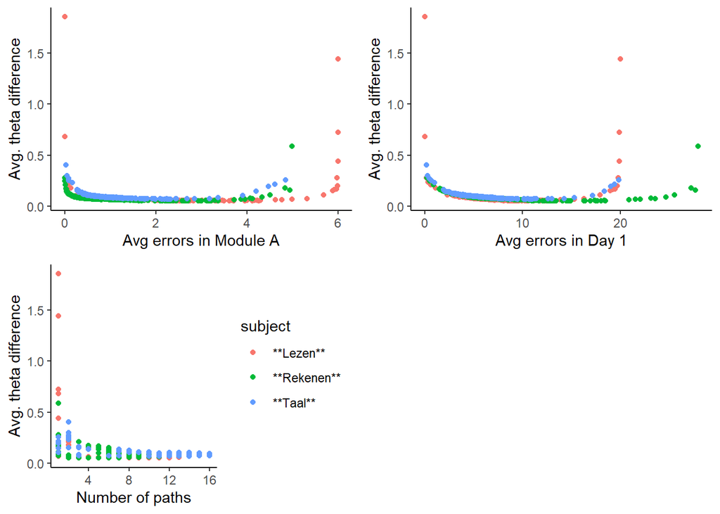

### Assumptions

There are many options in tackling issues regarding the violations of assumptions in ANCOVA (and in linear models in general). For example, one can use so-called [Generalized Linear Models](https://en.wikipedia.org/wiki/Generalized_linear_model), [nonparameteric](https://en.wikipedia.org/wiki/Nonparametric_statistics) alternatives, [robust analyses](https://en.wikipedia.org/wiki/Robust_statistics) or account for the violations directly. Since the aim of this analysis is to illustrate, as simply as possible, whether there are differences between the three courses in the discrepancy between the true and estimated ability, after controlling for the above-mentioned covariates, it is best to stick with the most simple analysis, of course, while always treating the p-values with caution, since certain violations of the assumptions may decrease the estimates of the SE and consequently influence the p-values. However, in the results that follow the obtained p-values were very low, indicating that there is an effect, even if some of the (non accounted for) violations made them smaller than they truly are. In other words, if violations of the assumptions are an expected part of the analysis and if they are communicated then one can proceed to *cautiously* interpret the results (for more elaborations, see, Field, Miles, & Field (2012), Chapter 11).

#### Normality

When performing an ANCOVA and related analyses, one assumption that is often the first to be checked, is whether the frequency distribution of the dependent variable (approximately) follows a normal distribution. On the left-hand side of the plot below, a histogram of the observed, average theta differences (for all three courses together) is presented. It is clear, and expected, that most of the observations are accumulated around 0, followed by a sharp decrease, which is a clear sign of non-normality. One suggested solution, that is often taken, is to transform the outcome variable, making the highly skewed data more normal, while at the same time keeping the internal relationship of the data points the same. The figure on the right-hand side shows the inverse of the outcome variable. Even though it is now slightly negatively skewed, based on current statistical literature, this assumption doesn’t expect the frequency of the outcome to *perfectly* follow a normal distribution but needs to not *seriously* deviate from normality, this is often confused with the assumption that the residuals need to be normally distributed around zero (see [this](https://towardsdatascience.com/is-normal-distribution-necessary-in-regression-how-to-track-and-fix-it-494105bc50dd) resource for further information).

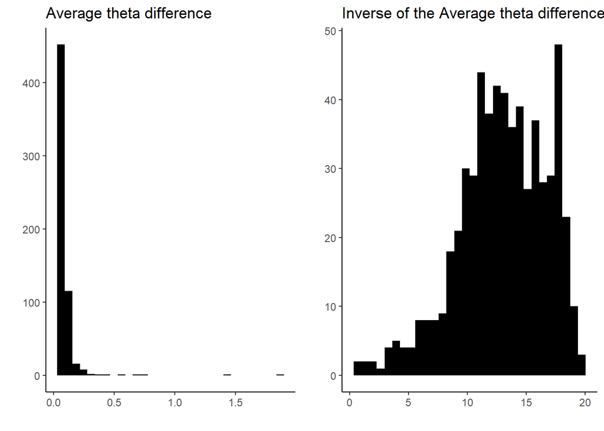

#### Outliers

Another assumption is the presence of outliers. As it has been discussed above, there tend to be larger discrepancies between the true and average re-estimated latent abilities when observing extreme (positive and negative) values for the true theta, which would represent outlines in this analysis. However, keeping these values in is a very important aspect of what is aimed to be achieved. Since the main objective is to see whether differences between the groups can be observed, even after controlling for the covariates.

#### Equality of variance

[Levene’s test](https://en.wikipedia.org/wiki/Levene%27s_test) for equality of variances is not significant, *F*(2, 597) = 2.06, *p* = .13, meaning that the null hypothesis stating that the variances in the outcome variable between the three subjects are the same, cannot be rejected. In other words, this assumption has been met.

|  | Df | F value | Pr(>F) |
| --- | --- | --- | --- |
| group | 2 | 2.057541 | 0.1286729 |
|  | 597 | / | / |

#### Homogeneity of regression slopes

The assumption of homogeneity of regression slopes is violated, since the regression line for Lezen crosses the ones for Taal and Rekenen, for all three covariates (see the plots in the Appendix). However, since it was expected that this would happen due to the nature of the data, it is proceeded with interpreting the results.

### Results

For both models, the [Type III Sum of Squares](https://towardsdatascience.com/anovas-three-types-of-estimating-sums-of-squares-don-t-make-the-wrong-choice-91107c77a27a) is observed.

#### ANOVA

|  | Df | Sum Sq | Mean Sq | F value | Pr(>F) |
| --- | --- | --- | --- | --- | --- |
| subject | 1 | 1345.400 | 1345.3995 | 115.4018 | 0 |
| Residuals | 598 | 6971.722 | 11.6584 | / | / |

#### ANCOVA

To test whether when “equalizing” the average ability differences on covariates such as the number of mistakes and number of different paths taken in the MST, two ANCOVA models were fitted. The first contained all three covariates and in the second the average number of mistakes in module A was taken out, the reasoning behind this was that the number of mistakes in Day 1 contains the number of mistakes in Module A, thus fitting a more complex model did not add any value to the analyses (the difference and resulting F-test value was the same).

|  | Sum Sq | Df | F value | Pr(>F) |
| --- | --- | --- | --- | --- |
| (Intercept) | 3358.377 | 1 | 467.8475 | 0 |
| avg.error.Day1 | 1715.180 | 1 | 238.9377 | 0 |
| n.paths | 1753.720 | 1 | 244.3065 | 0 |
| subject | 1929.713 | 1 | 268.8237 | 0 |
| Residuals | 4278.301 | 596 | / | / |

#### Post hoc tests

Now since a significant difference between at least two of the three classes, it is time to inspect where exactly are these differences located. For this, [post hoc tests](https://en.wikipedia.org/wiki/Post_hoc_analysis) with a *Bonferroni correction* for the alpha value was applied.

| group1 | group2 | df | statistic | p.adj | p.adj.signif |
| --- | --- | --- | --- | --- | --- |
| Lezen | Rekenen | 595 | 1.8409 | 0.1984 | ns |
| Lezen | Taal | 595 | 18.4007 | 0.0000 | **** |
| Rekenen | Taal | 595 | 15.4536 | 0.0000 | **** |

As can be seen from the table above, significant differences for the means of the *inverse* average ability discrepancies, when controlling for the number of mistakes in Day 1 and the number of paths, appear between the subjects Taal and Lezen and Taal and Rekenen. The main conclusion from this analysis, which is connected to what was observed in the previous sections, is that the Rekenen MST, by far, produces the smallest discrepancies between the true and the estimated ability. Furthermore, these results *hint* that *when controlling for important factors* in the MST, the lead, with respect to the highest discrepancies, is taken on by Taal. However, this second observation should be considered with caution due to all the aforementioned issues regarding the violations of the assumptions and also the problems with Null Hypothesis Significance Testing in general. Additionally, another aspect that might cast doubt on this last observation are covariates that were not included in the present analysis. For example, one such covariate is the average weights of the items in Module A, with Lezen having the highest value (5.3) and Taal the lowest (3.2), with Rekenen in the middle with 4.

It should be noted that due to the non-linear relationships between the dependent variable and the predictors (see, the plots above) a quadratic term was added for each of the covariates, and no differences in the results were observed whatsoever. Thus, it was decided to continue with the more simple analysis.

# **Classification Errors (Simulation 2)**

## Outline

*Simulation 1* aimed to look at how the MSTs of the three subjects react and differ from each other when considering different aspects of the test design. The aim of this simulation, on the other hand, is to look at all the three tests together, and hopefully try to understand how the number of mistakes made in Modules A in all three MST subjects, relates to the classification in classes of secondary education and derive certain threshold values above which misclassifications tend to appear. For this simulation, the observed ability estimates (including the subject Schrijven), final test scores and associated classifications in secondary education for all students that participated in ACET 2021 were used. The average ability estimate for each subject represents the typical “student” for each of the 6 classes of secondary education. Afterwards, these true abilities were used to generate 1000 MST responses for each perfect student, resulting in 6000 different MST patterns per subject. Afterwards, functions that transform the ability estimates into reference scores, based on the rules used for ACET (see the table below), were programmed for all four subjects. Additionally, a function that classifies students in one of the 6 classes of secondary education based on their **total test score** was programmed. The test score is derived with a linear function of the reference scores for each subject. The weights in the linear function are based on long-term monitoring of students in the first three years of secondary education. The linear function is presented in the Appendix (note that Rekenen is the strongest predictor). This total test score roughly ranges from 500 to 550. It should be noted that derived test scores that were lower or higher than 500 and 550, respectively, were classified in *pro/bb* and *vwo*, i.e., the lowest and highest class respectively. In this section first, the classification errors as a function of the total number of mistakes in Modules A for all six secondary education classes are presented and discussed. Afterwards, based on the same simulation approach, threshold values above (and below) which students tend to be classified in a class of secondary education that is not the same as the one that corresponds to their true abilities, are calculated.

| Class | Score |
| --- | --- |
| *pro/bb* | 501-504 |
| *bb/kb* | 505-524 |
| *kb/gt* | 525-532 |
| *gt/havo* | 533-539 |
| *havo/vwo* | 540-544 |
| *vwo* | 545-550 |

## Classification errors vs total number of mistakes in Modules A

For each of the 1000 replicated MST responses for all six typical students the number of mistakes in Module A (for all three subjects), were calculated with the written `R` scripts used in the first simulation. Afterwards, the 1000 replicates were separated based on the number of mistakes in each subject. It should be noted that not all of the 6 typical students can have all possible combinations of mistakes, for example, a typical student of class *pro/bb* tends to make mistakes ranging from 16 (6 for Lezen, and 5 for Rekenen and Taal), to around 9. On the other hand, a typical student from *vwo* tends to make a low total number of mistakes. In the figure below the classification errors as a function of the total number of mistakes in Module A are presented for all six classes. A classification error is defined as the proportion of mismatches between the “true” class and the class that a student is classified in based on the scores derived when that student made a certain number of mistakes in Modules A. Since Shcrijven is administered via a liner test, the “true” ability for this subject will be re-used throughout, when calculating the classification errors, thus neutralizing the influence of this subject and only observing the classification errors caused by the subjects administered through an MST.

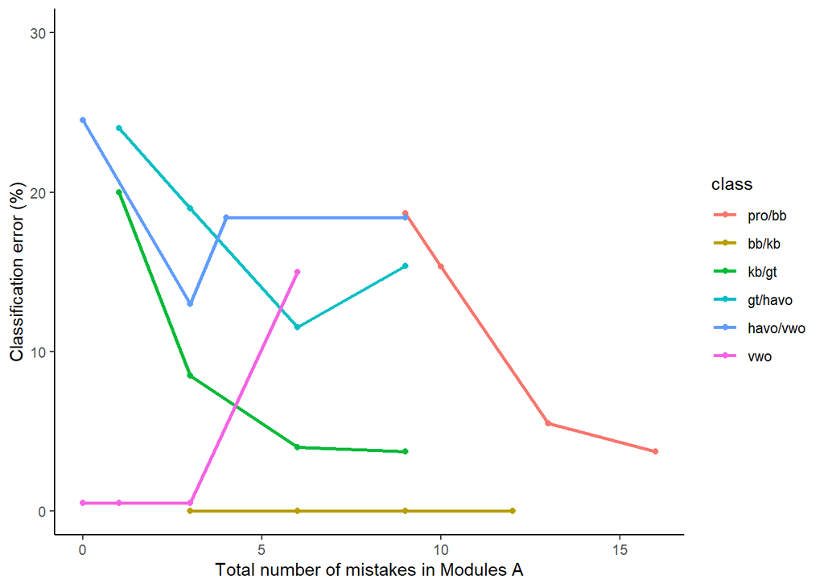

- The number of early mistakes does influence the classification in classes of secondary education;
- There amount of classification error as a function of the number of mistakes varies for the different classes;
- The amount of classification error for the medium proficient classes is dependent on the respective range of test scores for that particular class, regardless of the number of mistakes.

## Threshold values

In this last part of the project, the aim was focused on deriving certain threshold $\theta$ and consequently reference score values for each subject, above which misclassifications tend to appear for each of the six classes. For the aims of this analysis the same simulated data, like the one in the previous analysis was used. The ability difference between each of the 1000 simulated responses and the typical (true) ability for each of the six classes was calculated, by taking the absolute difference between the true (typical) and re-estimated ability for each subject. In order to see above which theta difference and reference score value differences appear, misclassifications were calculated for each of the six classes for every subject, while keeping the other two subjects constant (i.e., using their true theta values). The results are presented below.

### Lezen

| Class | Ability difference | Reference score |
| --- | --- | --- |
| *pro/bb* | 0.18 | 37 |
| *bb/kb* | / | / |
| *kb/gt* | / | / |
| *gt/havo* | / | / |
| *havo/vwo* | 0.24 | 72 |
| *vwo* | / | / |

For Lezen the only classes for which threshold values were found (meaning that classification mismatches were observed), was for *pro/bb* and *havo/wvo*. For *pro/bb* an absolute discrepancy between the true and the re-estimated ability of 0.18 and higher tends to lead to students being classified in *bb/kb*, this roughly corresponds to obtaining a score of 37 and higher on the Lezen test. For *havo/wvo* obtaining an ability discrepancy of 0.24, which corresponds to a reference score of 72 and higher results in a student being incorrectly slaccisifed to the higher class *vwo*.

### Rekenen

| Class | Ability difference | Reference score |
| --- | --- | --- |
| *pro/bb* | 0.19 | 12 |
| *bb/kb* | / | / |
| *kb/gt* | 0.17 | 28 |
| *gt/havo* | 0.19 | 33 |
| *havo/vwo* | 0.18 | 36 |
| *vwo* | / | / |

Rekenen appears to be a bit more sensitive to discrepancies between the true and the estimated ability, however, as already seen in *Simulation 1*, these discrepancies are rarely reached compared to the other two subjects. Based on the results, it appears that discrepancies of around 0.18 and above tend to lead to mismatches. Reference scores of 12, 28, 33 and 36 for *prob/bb*, *kb/gt*, *gt/havo* and *havo/wvo*, respectively should be treated with caution.

### Taal

| Class | Ability difference | Reference score |
| --- | --- | --- |
| *pro/bb* | 0.21 | 28 |
| *bb/kb* | / | / |
| *kb/gt* | 0.29 | 59 |
| *gt/havo* | / | / |
| *havo/vwo* | 0.37 | 44 |
| *vwo* | / | / |

The highest values of ability discrepancies tend to be present for Taal. Reference score values of 28, 59 and 44 should be treated with caution.

This analysis highlights $\theta$ discrepancies above which misclassification tend to appear, and it also gives an indication to, more carefully, treat students with certain reference scores on subjects when being classified in a secondary education class. It should be noted, however, that this analysis was performed conditional on perfect estimates on the other two subjects, in reality, all three MST’s give estimates of the ability and all three (may) contain a certain amount of discrepancy, leading to additional mismatches. Thus, this analysis fails to capture this important interaction, however, it still gives an indication of the number of the size of discrepancies on the latent ability that can be tolerated and also gives certain ranges of reference scores that should be treated with caution while classifying students into secondary education classes.

# **Conclusion**

This project aimed to explore to what extent are students able to recover from mistakes made in the early stages of the ACET MST. Due to the complexity of the ACET design, there was no single way to answer this research question, thus different (exploratory) analyses were performed. The main conclusion, consistent throughout all the analyses, was that the subject Rekenen possesses the highest possibility of recovery from early mistakes. This is in complete contrast to the subject Lezen, where mistakes made in Module A, influence the end ability estimate more than mistakes made at later stages. The difference in the possibility of recovery between Lezen and Taal remained vague throughout the analyses, which can be attributed to certain drawbacks of this study (discussed further below). It is quite logical and expected that higher discrepancies tend to appear for students located on the extremes of the latent distribution (which is not necessarily only a problem with MSTs) and that students in the middle of the continuum tend to have lower mismatches. However, the results from the second simulation show that due to the size of the total test score intervals for each of the six classes, the classes *gt/havo* and *havo/wvo* tend to have higher classification errors, regardless of the number of mistakes made. The (indefinite) recommendations that can be drawn from the analyses presented in this report are as follows:

- The Rekenen MST functions desirably, and no changes are needed;
- Latent ability discrepancies of ~0.2 and lower can generally be tolerated since no mismatches tend to appear;
- The Lezen MST needs to be treated with caution. The effects of possible changes and/or improvements of item content should be monitored and studied.
- Further research for the Taal MST is needed, especially with respect to the variability in the number of MST paths (relative to the other two subjects);
- The total test score rules for classifying students within the six classes of secondary education should be thoroughly inspected and revised for the classes *gt/havo* and *havo/wvo*. This can be done by possibly motioning students already classified in these classes and afterwards adjusting the total test score intervals accordingly;
- The threshold values derived in the last section should be kept in mind and might come in handy when calculating the reference scores for each student.

Future studies should focus on the item parameters within each of the MSTs, something that was completely left out in this project. Additionally, the item and test information functions should be taken into account when inspecting the unanswered issues regarding Lezen and Taal. The interplay between discrepancies on all three MST’s when deriving threshold values should be explored. Finally, the possibility of exploring the full ACET (used for all children) containing multiple module versions should be considered. It is the authors sincerest hope that this study can serve only as an initial exploration in this multidimensional topic, for which more elaborate research is needed.

# **References**

Bechger, T., Koops, J., Partchev, I., & Maris, G. (2021). *dexterMST: CML and bayesian calibration of multistage tests*. Retrieved from https://dexter-psychometrics.github.io/dexter

Cohen, J. (1994). The earth is round (p<. 05). *American Psychologist*, *49*, 997.

Field, A., Miles, J., & Field, Z. (2012). *Discovering statistics using r*. Sage publications.

Maris, G., Bechger, T., Koops, J., & Partchev, I. (2021). *Dexter: Data management and analysis of tests*. Retrieved from https://CRAN.R-project.org/package=dexter

R Core Team. (2021). *R: A language and environment for statistical computing*. Vienna, Austria: R Foundation for Statistical Computing.

Yan, D., Von Davier, A. A., & Lewis, C. (2016). *Computerized multistage testing: Theory and applications*. CRC Press.

# **Appendix**

### Mistakes in Module A

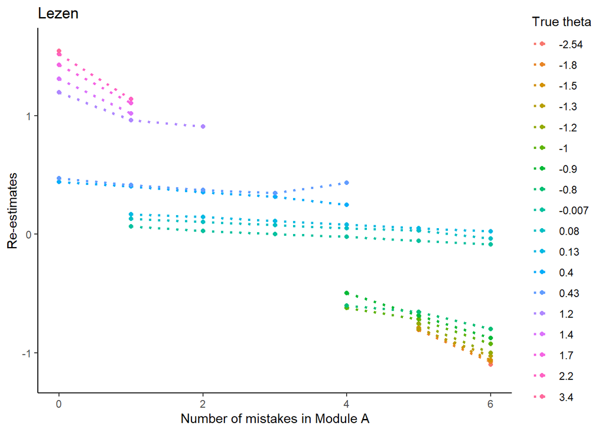

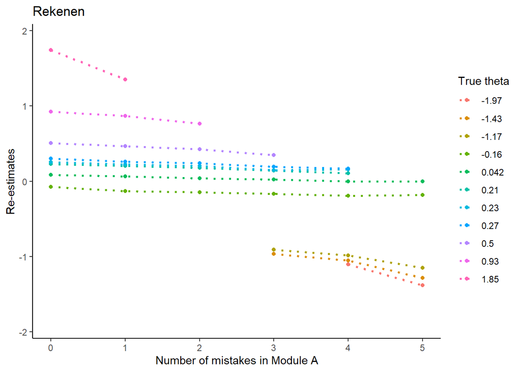

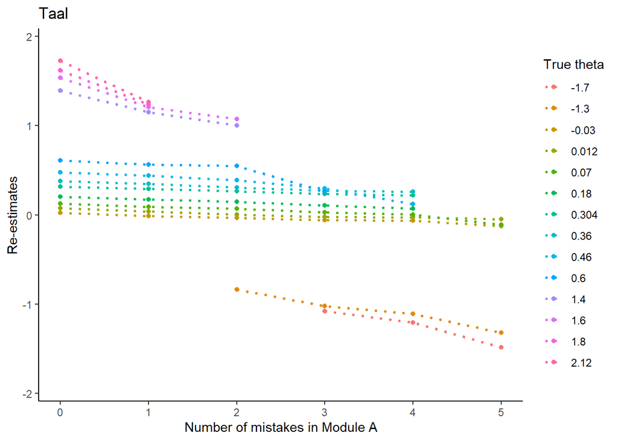

### Homogeneity of regression slopes

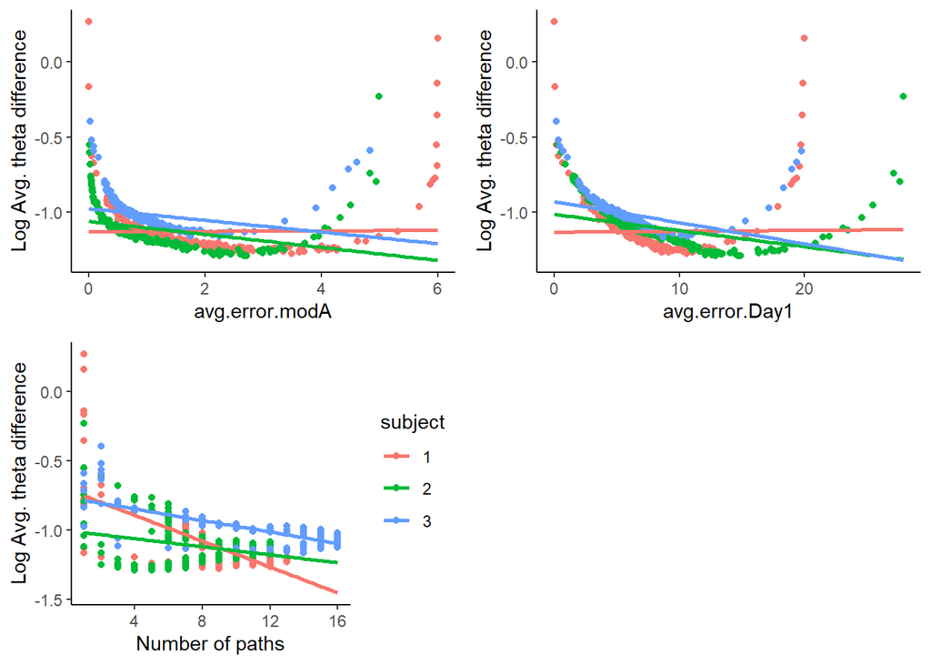

### Linear function for the total ACET test score

$$Total\ score = 484.75816 + Lezen * 0.234368499 + Taal * 0.232847623 + Rekenen * 0.706118502 + schrijven * 0.127383676$$

### Classification errors and total number of mistakes in modules A

| Classification error (proportion) | Number of mistakes | Class |
| --- | --- | --- |
| 0.04 | 16 | pro/bb |
| 0.06 | 13 | pro/bb |
| 0.15 | 10 | pro/bb |
| 0.19 | 9 | pro/bb |
| 0.00 | 12 | bb/kb |
| 0.00 | 9 | bb/kb |
| 0.00 | 6 | bb/kb |
| 0.00 | 3 | bb/kb |
| 0.04 | 9 | kb/gt |
| 0.04 | 6 | kb/gt |
| 0.09 | 3 | kb/gt |
| 0.20 | 1 | kb/gt |
| 0.15 | 9 | gt/havo |
| 0.12 | 6 | gt/havo |
| 0.19 | 3 | gt/havo |
| 0.24 | 1 | gt/havo |
| 0.18 | 9 | havo/vwo |
| 0.18 | 4 | havo/vwo |
| 0.13 | 3 | havo/vwo |
| 0.24 | 0 | havo/vwo |
| 0.15 | 6 | vwo |
| 0.00 | 3 | vwo |
| 0.00 | 1 | vwo |
| 0.00 | 0 | vwo |